# correlate-mirnas

## correlate-mirnas

*Last modified 2014-10-30. This document, R session image, knitr cache, figures, and other associated datasets are located in `cruncher:/inside/grotto/blin/trna-markers/prad/correlate-mirnas/`.*

```r
library(DESeq2)
library(BiocParallel)
library(R2HTML)
register(MulticoreParam(8)) # turn this off depending on your machine!
load('/inside/grotto/blin/trna-markers/feature-counts/counts.RData')
```

From feature-counts, we have four count matrices: `hg19_feature_nt_counts`, `hg19_feature_tp_counts`, `trna_nt_counts`, and `trna_tp_counts`. We are interested in correlations for the hg19 feature counts, since that's where the tRF counts are.

### Normalize counts

```r
hg19_feature_counts <- cbind(hg19_feature_tp_counts, hg19_feature_nt_counts)
hg19_feature_counts <- hg19_feature_counts[apply(hg19_feature_counts, 1, function(row) length(which(row > 0)) > 5), ]
hg19_feature_counts <- hg19_feature_counts[apply(hg19_feature_counts, 1, function(row) sum(row) > 10), ]
num_pairs <- length(colnames(hg19_feature_counts))/2
colData <- data.frame(row.names=colnames(hg19_feature_counts), condition=c(rep("tp", num_pairs), rep("nt", num_pairs)), type="single-read")
dds <- DESeqDataSetFromMatrix(countData = hg19_feature_counts, colData = colData, design = ~ condition)
dds <- DESeq(dds)
res <- results(dds)
```

Uh oh, only `hsa-mir-31` survived the purge! Looks like we'll just have to work with it.

We don't need to run the entire DESeq analysis pipeline. The only thing of interest is the scaling factors which we can now apply to our hg19 feature counts.

```r
normalized_counts <- t(t(hg19_feature_counts) / sizeFactors(dds)) # R applies vectors on columns (genes), we want R to apply them on rows (samples) for size factors
```

We should confirm that the normalization did a good job by making an MA plot.

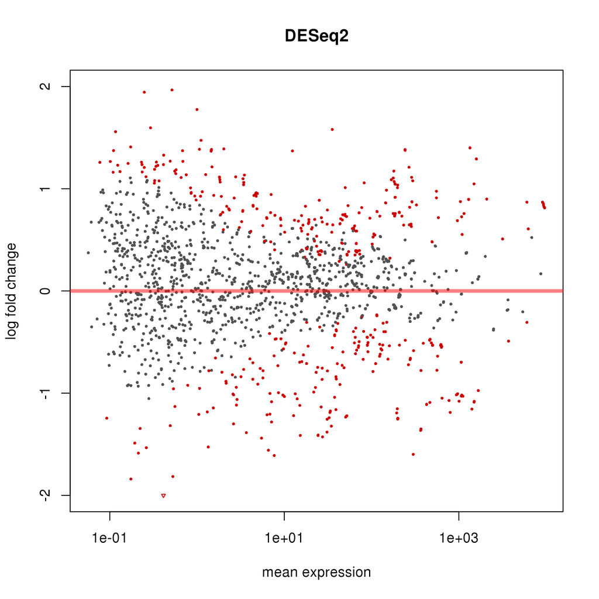

```r
plotMA(res, main="DESeq2", ylim=c(-2, 2))
```

### Correlation

The correlation will be performed on a matrix of fold changes. I'm not sure whether I should take the log<sub>2</sub> fold change before then. I do in this case, to minimize heteroscedasticity - reduce the variability between sub-populations, which in this case is individual genes or groups of genes. Since these are `log2` values, and there are fragments with counts of 0, we will use Laplacian smoothing (add a pseudocount of 1) to avoid `-Inf` values.

```r
# NT normalized counts - TP normalized counts
fold_changes <- log2(normalized_counts[, (num_pairs+1):(num_pairs*2)]+1) - log2(normalized_counts[, 1:num_pairs]+1)
```

I also have to choose between Pearson's r and Spearman's \rho. Apparently, Pearson's r has more power and finds linear (as opposed to monotonic) relationships, so I'll start with that.

```r
correlations <- cor(t(fold_changes), method = "pearson") # function operates on columns, so need to get features onto columns.
```

```r
mir_corr <- correlations[, 2679] # isolate for miRNAs
```

For this analysis, these are the most strongest negative and positive correlations with mir-hsa-31.

```r
mir_corr[order(mir_corr, decreasing = TRUE)][1:10]
```

```
##                      hsa-mir-31       tRNA-Trp-CCA-3-3_fivefrag
##                       1.0000000                       0.4328069
##       tRNA-Trp-CCA-3-1_fivefrag       tRNA-Trp-CCA-3-2_fivefrag
##                       0.4314253                       0.4248387
##       tRNA-Trp-CCA-4-1_fivefrag       tRNA-Tyr-GTA-1-1_fivefrag
##                       0.4183908                       0.3849132
##       tRNA-Tyr-GTA-2-1_fivefrag chr17.numttRNA1-LysTTT_fivefrag
##                       0.3816789                       0.3776659
##   chr9.numttRNA3-SerTGA_trailer        tRNA-Leu-AAG-2-2_trailer
##                       0.3772353                       0.3769512
```

```r
mir_corr[order(mir_corr)][1:10]
```

```
##            tRNA-Pro-TGG-3-4_trailer            tRNA-Pro-TGG-3-3_trailer
##                          -0.4449788                          -0.4449788
##         tRNA-Asn-GTT-19-1_threefrag           tRNA-Met-CAT-6-1_fivefrag
##                          -0.4385339                          -0.4231255
##           tRNA-Met-CAT-1-1_fivefrag           tRNA-Cys-GCA-5-1_fivefrag
##                          -0.4205996                          -0.4086018
##          tRNA-Asn-GTT-19-1_fivefrag          tRNA-Ile-TAT-1-1_threefrag
##                          -0.3957836                          -0.3651045
##            tRNA-Met-CAT-3-2_trailer chr6_cox_hap2.tRNA18-MetCAT_trailer
##                          -0.3645755                          -0.3645755
```

### Cluster

We can also cluster the features by their fold changes in the 52 samples.